# Principios de análisis multivariado

Felipe Calvo Cepeda - fcalvoc@unal.edu.co | Universidad Nacional de Colombia

2020

## Instalar librerías

```r
install.packages("Amelia")
install.packages("mvnmle")
install.packages("BaylorEdPsych")
install.packages("reshape2")
install.packages("FactoMineR")
install.packages("factoextra")
install.packages("corrplot")
```

## Cargar librerías

```r
library("readxl")
library("tidyverse")
library("Amelia")
library("mvnmle")
library("BaylorEdPsych")
library("car")
library("ggplot2")
library("GGally")
library("reshape2")
library("FactoMineR")
library("factoextra")
library("corrplot")
```

## Importar datos

```r
read_xlsx(
  path = "data/Boston_Housing.xlsx",
  sheet="Data"
) -> boston

## Revisar la estructura inicial de los datos
str(boston)
```

```
## tibble [506 x 14] (S3: tbl_df/tbl/data.frame)
##  $ CRIM   : num [1:506] 0.00632 0.02731 0.02729 0.03237 0.06905 ...
##  $ ZN     : num [1:506] 18 0 0 0 0 0 12.5 12.5 12.5 12.5 ...
##  $ INDUS  : num [1:506] 2.31 7.07 7.07 2.18 2.18 2.18 7.87 7.87 7.87 7.87 ...
##  $ CHAS   : num [1:506] 0 0 0 0 0 0 0 0 0 0 ...
##  $ NOX    : num [1:506] 0.538 0.469 0.469 0.458 0.458 0.458 0.524 0.524 0.524 0.524 ...
##  $ RM     : num [1:506] 6.58 6.42 7.18 7 7.15 ...
##  $ AGE    : num [1:506] 65.2 78.9 61.1 45.8 54.2 58.7 66.6 96.1 100 85.9 ...
##  $ DIS    : num [1:506] 4.09 4.97 4.97 6.06 6.06 ...
##  $ RAD    : num [1:506] 1 2 2 3 3 3 5 5 5 5 ...
##  $ TAX    : num [1:506] 296 242 242 222 222 222 311 311 311 311 ...
##  $ PTRATIO: num [1:506] 15.3 17.8 17.8 18.7 18.7 18.7 15.2 15.2 15.2 15.2 ...
##  $ B      : num [1:506] 397 397 393 395 397 ...
##  $ LSTAT  : num [1:506] 4.98 9.14 4.03 2.94 5.33 ...
##  $ MEDV   : num [1:506] 24 21.6 34.7 33.4 36.2 28.7 22.9 27.1 16.5 18.9 ...
```

```r
## Convierto variables respectivas a factores
factores <- c("CHAS")
boston %>% mutate_at(factores,factor) -> data

## Revisar la estructura actualizada de los datos
str(data)
```

```
## tibble [506 x 14] (S3: tbl_df/tbl/data.frame)
##  $ CRIM   : num [1:506] 0.00632 0.02731 0.02729 0.03237 0.06905 ...
##  $ ZN     : num [1:506] 18 0 0 0 0 0 12.5 12.5 12.5 12.5 ...
##  $ INDUS  : num [1:506] 2.31 7.07 7.07 2.18 2.18 2.18 7.87 7.87 7.87 7.87 ...
##  $ CHAS   : Factor w/ 2 levels "0","1": 1 1 1 1 1 1 1 1 1 1 ...
##  $ NOX    : num [1:506] 0.538 0.469 0.469 0.458 0.458 0.458 0.524 0.524 0.524 0.524 ...
##  $ RM     : num [1:506] 6.58 6.42 7.18 7 7.15 ...
##  $ AGE    : num [1:506] 65.2 78.9 61.1 45.8 54.2 58.7 66.6 96.1 100 85.9 ...
##  $ DIS    : num [1:506] 4.09 4.97 4.97 6.06 6.06 ...
##  $ RAD    : num [1:506] 1 2 2 3 3 3 5 5 5 5 ...
##  $ TAX    : num [1:506] 296 242 242 222 222 222 311 311 311 311 ...
##  $ PTRATIO: num [1:506] 15.3 17.8 17.8 18.7 18.7 18.7 15.2 15.2 15.2 15.2 ...
##  $ B      : num [1:506] 397 397 393 395 397 ...
##  $ LSTAT  : num [1:506] 4.98 9.14 4.03 2.94 5.33 ...
##  $ MEDV   : num [1:506] 24 21.6 34.7 33.4 36.2 28.7 22.9 27.1 16.5 18.9 ...
```

```r
## Le decimos a R que vamos a trabajar con esos datos y se los ponemos "en primer plano"
attach(data)

## Veamos los primeros registros
head(data)
```

```
## # A tibble: 6 x 14
##      CRIM    ZN INDUS CHAS    NOX    RM   AGE   DIS   RAD   TAX PTRATIO     B
##     <dbl> <dbl> <dbl> <fct> <dbl> <dbl> <dbl> <dbl> <dbl> <dbl>   <dbl> <dbl>
## 1 0.00632    18  2.31 0     0.538  6.58  65.2  4.09     1   296    15.3  397.
## 2 0.0273      0  7.07 0     0.469  6.42  78.9  4.97     2   242    17.8  397.
## 3 0.0273      0  7.07 0     0.469  7.18  61.1  4.97     2   242    17.8  393.
## 4 0.0324      0  2.18 0     0.458  7.00  45.8  6.06     3   222    18.7  395.
## 5 0.0690      0  2.18 0     0.458  7.15  54.2  6.06     3   222    18.7  397.
## 6 0.0298      0  2.18 0     0.458  6.43  58.7  6.06     3   222    18.7  394.
## # ... with 2 more variables: LSTAT <dbl>, MEDV <dbl>
```

## Información sobre el conjunto de datos

### Información general

Los datos de la vivienda contienen 506 secciones censales de Boston del censo de 1970. La base de datos Boston Housing contiene los datos originales de Harrison y Rubinfeld (1979).

### Variables

- **CRIM**: crimen per cápita por ciudad
- **ZN**: proporción de terrenos residenciales divididos en zonas para lotes de más de 25,000 pies cuadrados
- **INDUS**: proporción de acres de negocios no minoristas por ciudad
- **CHAS**: variable dummy de Charles River (= 1 si el limita con el río, 0 de lo contrario)
- **NOX**: concentración de óxidos nítricos (partes por 10 millones)
- **RM**: número promedio de habitaciones por vivienda
- **AGE**: proporción de unidades ocupadas por sus propietarios construidas antes de 1940
- **DIS**: distancias ponderadas a cinco centros de empleo de Boston
- **RAD**: índice de accesibilidad a las autopistas radiales
- **TAX**: tasa de impuesto a la propiedad de valor completo por USD 10,000
- **PTRATIO**: proporción de estudiantes por profesor
- **B**: 1000*(Bk - 0,63)^ 2, donde Bk es la proporción de negros por ciudad
- **LSTAT**: porcentaje de población clase baja (menores ingresos)
- **MEDV**: valor mediano de las viviendas ocupadas por sus propietarios (en miles de dólares). Esta es la variable objetivo.

### Fuente

Harrison, D. and Rubinfeld, D.L. (1978). Hedonic prices and the demand for clean air. Journal of Environmental Economics and Management, 5, 81–102.

## Dimensionalidad de los datos

```r
dim(data)
```

```
## [1] 506  14
```

- 506 municipios/pueblos - Número de filas
- 14 variables - Número de columnas

## Limpieza de datos

### Datos faltantes

Vamos a comprobar datos faltantes sumando NA por columna (es decir, para cada variable) y además los graficaremos mediante el método **missmap()** de la librería Amelia.

```r
## Conteo de datos faltantes por variable
data %>% map_df(is.na) %>% colSums()
```

```
##    CRIM      ZN   INDUS    CHAS     NOX      RM     AGE     DIS     RAD     TAX
##       0       0       0       0       0       0       0       0       0       0
## PTRATIO       B   LSTAT    MEDV
##       0       0       0       0
```

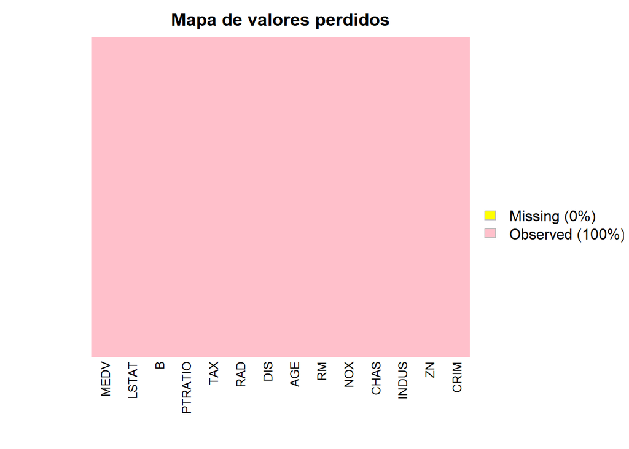

```r
## Gráfica de datos faltantes
missmap(data,
        col=c('yellow','pink'),
        main='Mapa de valores perdidos',
        y.at=1,
        y.labels='',
        legend=TRUE)
```

En este caso no hay datos perdidos. Sin embargo, en muchos casos de la vida real es posible que nos falten datos. Si son pocos los faltantes los podemos imputarlos, si son muchos surgen dos escenarios:

- Que los datos faltantes sean aleatorios. En esos casos se podrían correr métodos de imputación múltiple (p.e. MICE).
- Que hayan patrones de pérdida de datos, lo que puede indicar un problema en la recolección, captura y distribución de la base de datos.

### Datos atípicos

Para detectar datos atípicos podemos seguir dos caminos:

- Buscar datos atípicos para cada variable (columna). Para esto podríamos usar boxplots.
- Buscar filas que consistentemente tengan datos atípicos en todas las celdas.

Dado que el camino de revisar cada variable ya sabemos cómo hacerlo, miremos el segundo camino que es propio del análisis multivariado.

Para esto vamos a definir la **distancia de Cook**: dado un modelo de regresión, se calcula la influencia ejercida por cada fila en el resultado previsto y el interés es detectar filas cuyos resultados observados sean muy distintos a los resultados predichos.

```r
modelo.regresion <- lm(MEDV ~ ., data=data)
cooksd <- cooks.distance(modelo.regresion)
```

En ese sentido, diremos que tendremos una fila que representa una onservación atípica si el valor observado es superior a 4 veces el promedio (no es un límite estricto).

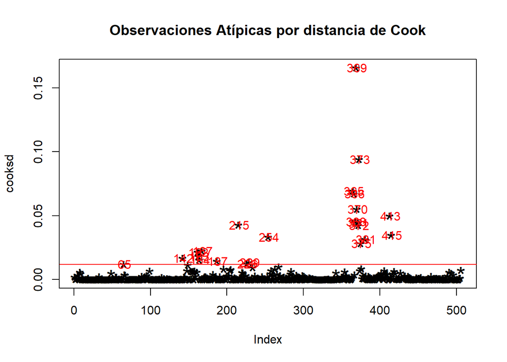

```r
# Gráfica de la distancia de Cook
plot(cooksd, pch="*", cex=2, main="Observaciones Atípicas por distancia de Cook")
# Superponemos el límite definido
abline(h = 4*mean(cooksd, na.rm=T), col="red")
# Agregamos etiquetas de identificación para observaciones atípicas
text(x=1:length(cooksd)+1, y=cooksd, labels=ifelse(cooksd>4*mean(cooksd, na.rm=T),names(cooksd),""), col="red")
```

```r
## Número de filas a revisar
atipicas <- which((cooksd>4*mean(cooksd, na.rm=T)) == "TRUE")
atipicas
```

```
##  65 142 162 163 164 167 187 215 226 229 254 365 366 368 369 370 371 372 373 375
##  65 142 162 163 164 167 187 215 226 229 254 365 366 368 369 370 371 372 373 375
## 381 413 415
## 381 413 415
```

Esta revisión de filas depende del problema en estudio. En este caso, es posible que existan viviendas demasiado costosas cuyo precio esté influenciado por otras variables.

Además, hay que tener en cuenta que estos datos corresponden a un censo y en los censos puede haber numerosos casos excepcionales.

La revisión y las decisiones que tome el analista cambiarían sustancialmente si los datos en cambio provinieran de una muestra, en las cuales los datos atípicos son menos frecuentes.

## Análisis descriptivo

```r
## Resumen básico de datos
summary(data)
```

```
##       CRIM                ZN             INDUS       CHAS         NOX
##  Min.   : 0.00632   Min.   :  0.00   Min.   : 0.46   0:471   Min.   :0.3850
##  1st Qu.: 0.08205   1st Qu.:  0.00   1st Qu.: 5.19   1: 35   1st Qu.:0.4490
##  Median : 0.25651   Median :  0.00   Median : 9.69           Median :0.5380
##  Mean   : 3.61352   Mean   : 11.36   Mean   :11.14           Mean   :0.5547
##  3rd Qu.: 3.67708   3rd Qu.: 12.50   3rd Qu.:18.10           3rd Qu.:0.6240
##  Max.   :88.97620   Max.   :100.00   Max.   :27.74           Max.   :0.8710
##        RM             AGE              DIS              RAD
##  Min.   :3.561   Min.   :  2.90   Min.   : 1.130   Min.   : 1.000
##  1st Qu.:5.886   1st Qu.: 45.02   1st Qu.: 2.100   1st Qu.: 4.000
##  Median :6.208   Median : 77.50   Median : 3.207   Median : 5.000
##  Mean   :6.285   Mean   : 68.57   Mean   : 3.795   Mean   : 9.549
##  3rd Qu.:6.623   3rd Qu.: 94.08   3rd Qu.: 5.188   3rd Qu.:24.000
##  Max.   :8.780   Max.   :100.00   Max.   :12.127   Max.   :24.000
##       TAX           PTRATIO            B              LSTAT
##  Min.   :187.0   Min.   :12.60   Min.   :  0.32   Min.   : 1.73
##  1st Qu.:279.0   1st Qu.:17.40   1st Qu.:375.38   1st Qu.: 6.95
##  Median :330.0   Median :19.05   Median :391.44   Median :11.36
##  Mean   :408.2   Mean   :18.46   Mean   :356.67   Mean   :12.65
##  3rd Qu.:666.0   3rd Qu.:20.20   3rd Qu.:396.23   3rd Qu.:16.95
##  Max.   :711.0   Max.   :22.00   Max.   :396.90   Max.   :37.97
##       MEDV
##  Min.   : 5.00
##  1st Qu.:17.02
##  Median :21.20
##  Mean   :22.53
##  3rd Qu.:25.00
##  Max.   :50.00
```

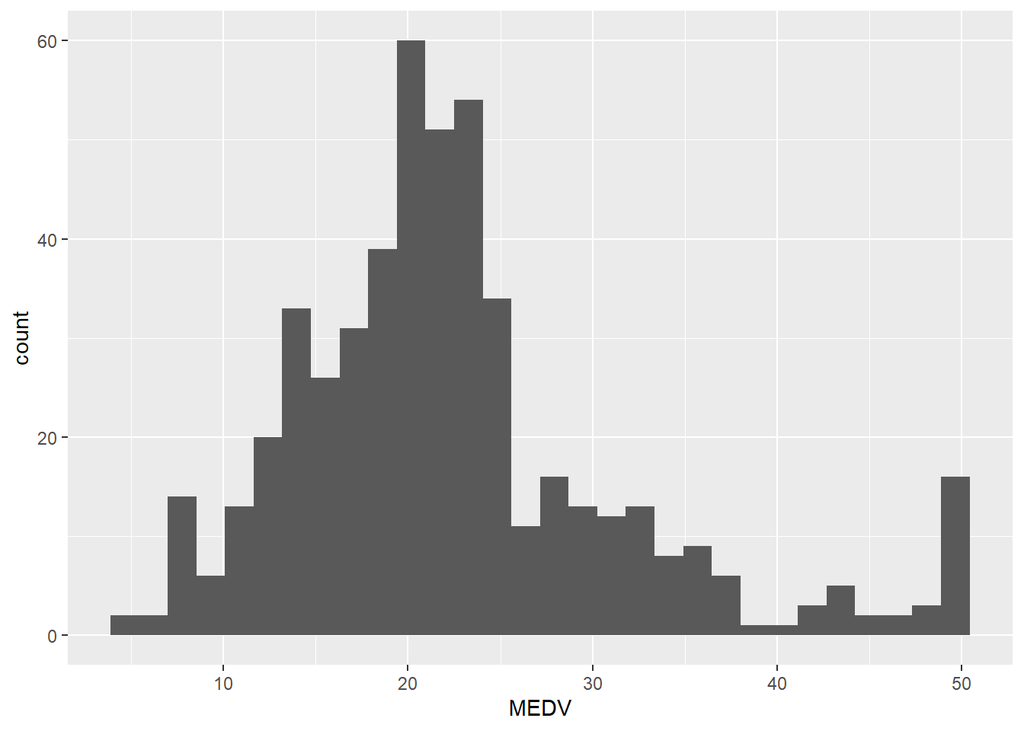

```r
## Resumen gráfico
## Usamos el método para graficar histogramas
## Seleccionamos como objetivo la variable quality
ggplot(data, aes(MEDV)) +
    geom_histogram()
```

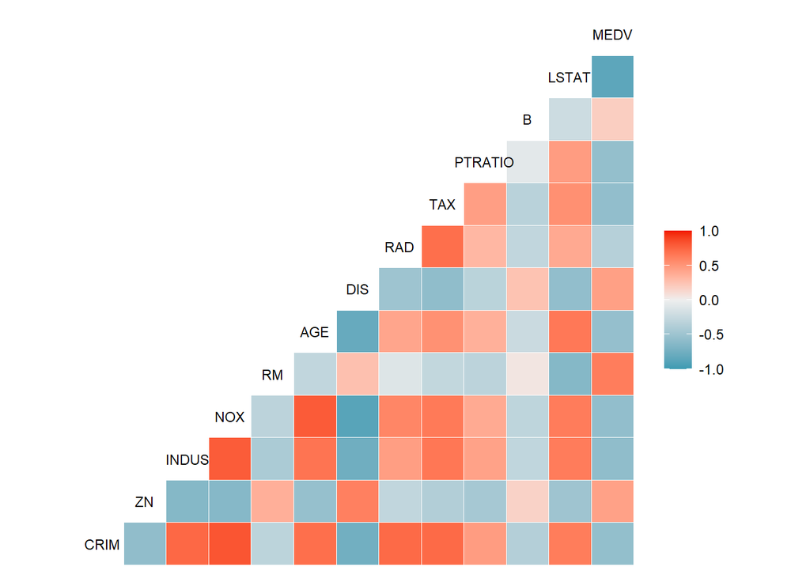

```r
## Correlogramas
ggcorr(
  data,
  method = c("everything", "spearman"),
  size = 3
  )
```

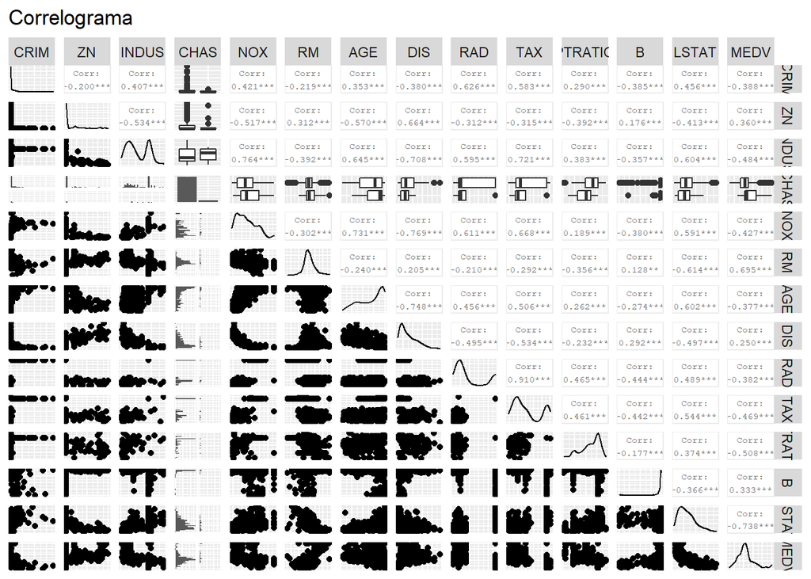

```r
ggpairs(
  data,
  title="Correlograma",
  axisLabels = "none",
  upper = list(continuous = wrap("cor", size = 2))
  )
```

> Dado que tenemos numerosas variables altamente correlacionadas con nuestra variable de respuesta, podemos hacer un filtro más fuerte y descartar aquellas que tengan una correlación menor a 0.35 en valor absoluto. En ese orden de ideas descartaremos las variables **DIS** y **B**.

### Efecto de las variables

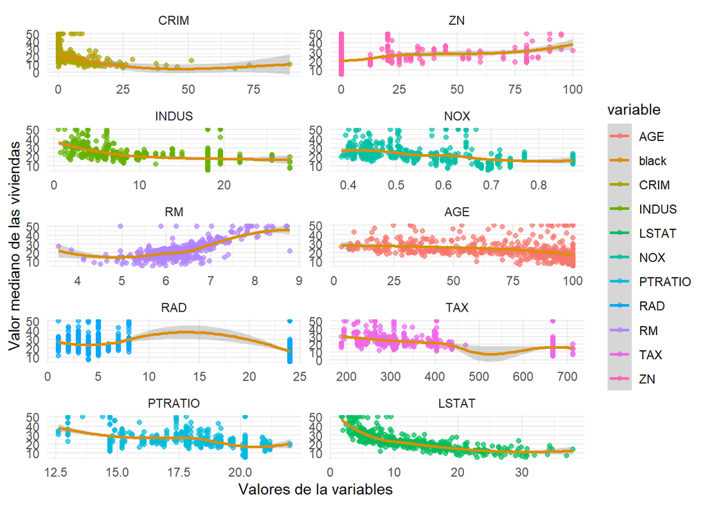

```r
data %>%
  select(c(CRIM, ZN, INDUS, NOX, RM, AGE, RAD, TAX, PTRATIO, LSTAT, MEDV)) %>%
  melt(id.vars = "MEDV") %>%
  ggplot(aes(x = value, y = MEDV, colour = variable)) +
  geom_point(alpha = 0.7) +
  stat_smooth(aes(colour = "black")) +
  facet_wrap(~variable, scales = "free", ncol = 2) +
  labs(x = "Valores de la variables", y = "Valor mediano de las viviendas") +
  theme_minimal()
```

## Ajuste de un modelo de regresión múltiple

```r
modelo <- lm(MEDV ~ CRIM + ZN + INDUS + NOX + RM + AGE + RAD + TAX + PTRATIO + LSTAT, data = data)

## Resumen del modelo
summary(modelo)
```

```
##
## Call:
## lm(formula = MEDV ~ CRIM + ZN + INDUS + NOX + RM + AGE + RAD +
##     TAX + PTRATIO + LSTAT, data = data)
##
## Residuals:
##      Min       1Q   Median       3Q      Max
## -13.7789  -3.1452  -0.7711   1.9299  28.0633
##
## Coefficients:
##               Estimate Std. Error t value Pr(>|t|)
## (Intercept)  28.916271   4.879364   5.926 5.81e-09 ***
## CRIM         -0.099421   0.034788  -2.858 0.004445 **
## ZN            0.006057   0.013503   0.449 0.653928
## INDUS         0.132339   0.064195   2.062 0.039775 *
## NOX         -10.300472   3.925692  -2.624 0.008962 **
## RM            4.108519   0.442563   9.283  < 2e-16 ***
## AGE           0.035199   0.013518   2.604 0.009493 **
## RAD           0.320195   0.070715   4.528 7.47e-06 ***
## TAX          -0.014832   0.004008  -3.700 0.000239 ***
## PTRATIO      -1.070387   0.139284  -7.685 8.29e-14 ***
## LSTAT        -0.579745   0.053665 -10.803  < 2e-16 ***
## ---
## Signif. codes:  0 '***' 0.001 '**' 0.01 '*' 0.05 '.' 0.1 ' ' 1
##
## Residual standard error: 5.1 on 495 degrees of freedom
## Multiple R-squared:  0.6987, Adjusted R-squared:  0.6926
## F-statistic: 114.8 on 10 and 495 DF,  p-value: < 2.2e-16
```

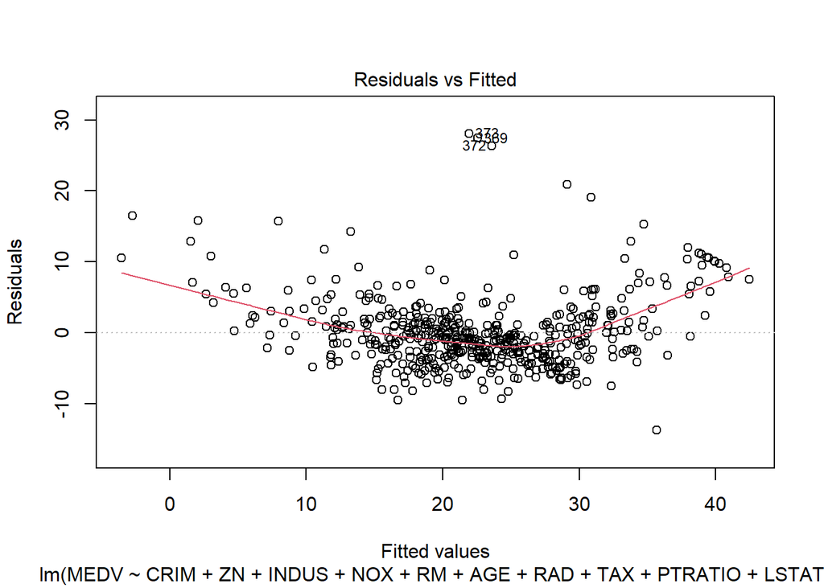

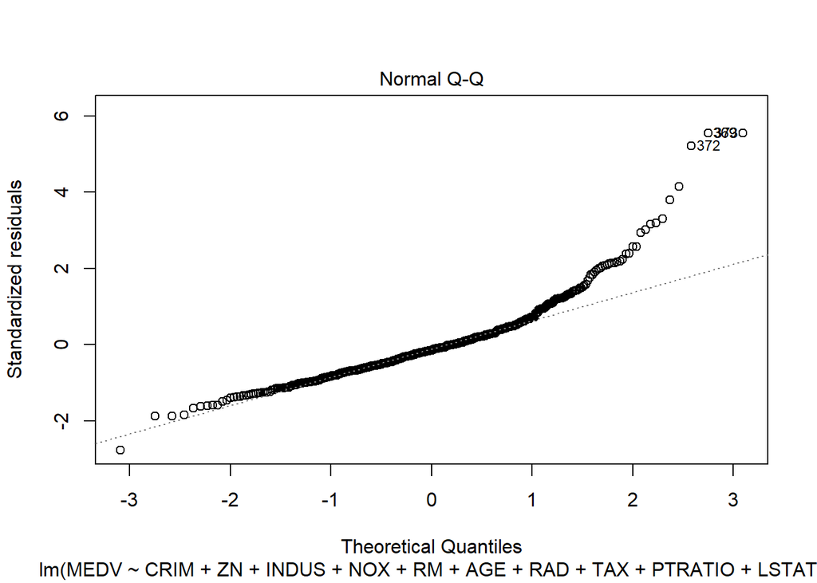

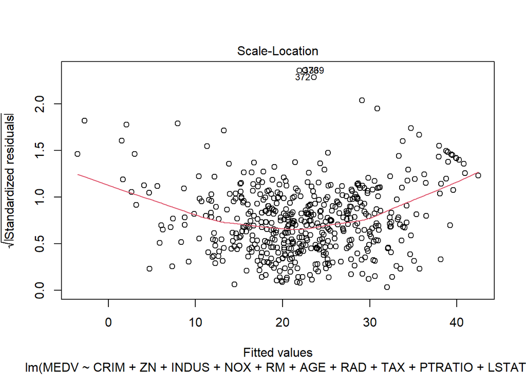

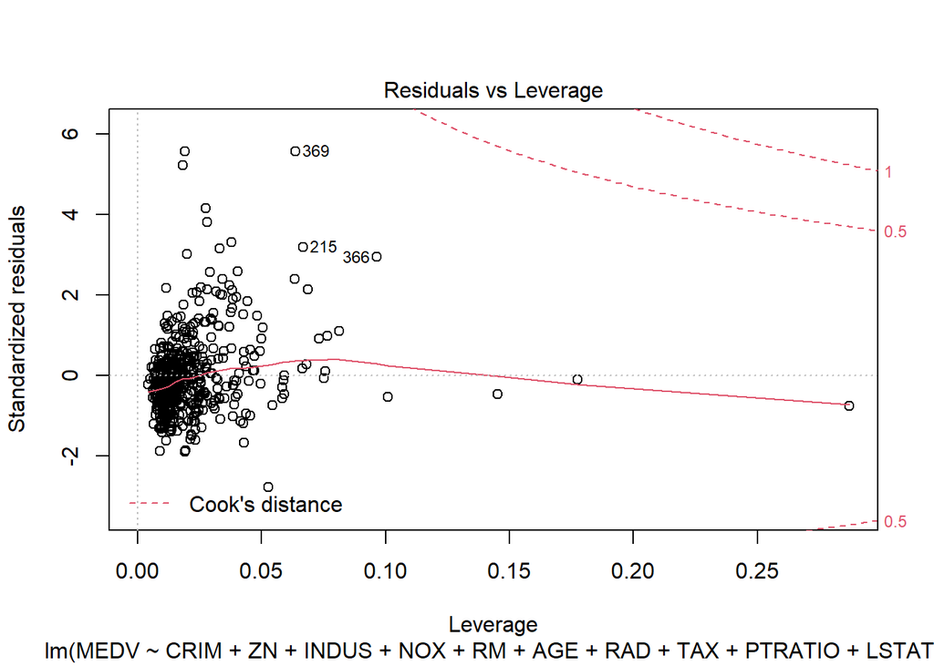

```r
## Validación del modelo
plot(modelo)
```

## Ajuste de un análisis de componentes principales

```r
## Declaro un vector con las variables que quiero agrupar
var_interes = c("CRIM", "ZN", "INDUS", "NOX", "RM", "AGE", "RAD", "TAX", "PTRATIO", "LSTAT")

## Y estandarizo esas variables
data %>%
  select(var_interes) %>%
  mutate_all(scale) -> data_estandarizada
```

```
## Note: Using an external vector in selections is ambiguous.
## i Use `all_of(var_interes)` instead of `var_interes` to silence this message.
## i See <https://tidyselect.r-lib.org/reference/faq-external-vector.html>.
```

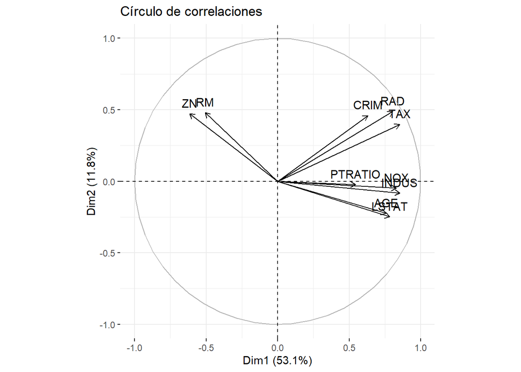

```r
## Ajusto componentes principales usando el método PCA()
acp = PCA(data_estandarizada,graph=F)

## Círculo de correlaciones entre variables
fviz_pca_var(acp, col.var = "black", title="Círculo de correlaciones")
```

```r
## Componentes principales
eig.val <- get_eigenvalue(acp)
eig.val
```

```
##        eigenvalue variance.percent cumulative.variance.percent
## Dim.1  5.30853032       53.0853032                    53.08530
## Dim.2  1.18488167       11.8488167                    64.93412
## Dim.3  1.04779968       10.4779968                    75.41212
## Dim.4  0.79773274        7.9773274                    83.38944
## Dim.5  0.53213639        5.3213639                    88.71081
## Dim.6  0.39186667        3.9186667                    92.62947
## Dim.7  0.27462043        2.7462043                    95.37568
## Dim.8  0.22353398        2.2353398                    97.61102
## Dim.9  0.17418911        1.7418911                    99.35291
## Dim.10 0.06470901        0.6470901                   100.00000
```

> Cuando el valor propio (eigenvalue) de un componente es superior a 1 se suele retener, es decir, la *combinación de variables al interior de un “componente”* es capaz de explicar más varianza que cada variable por separado.

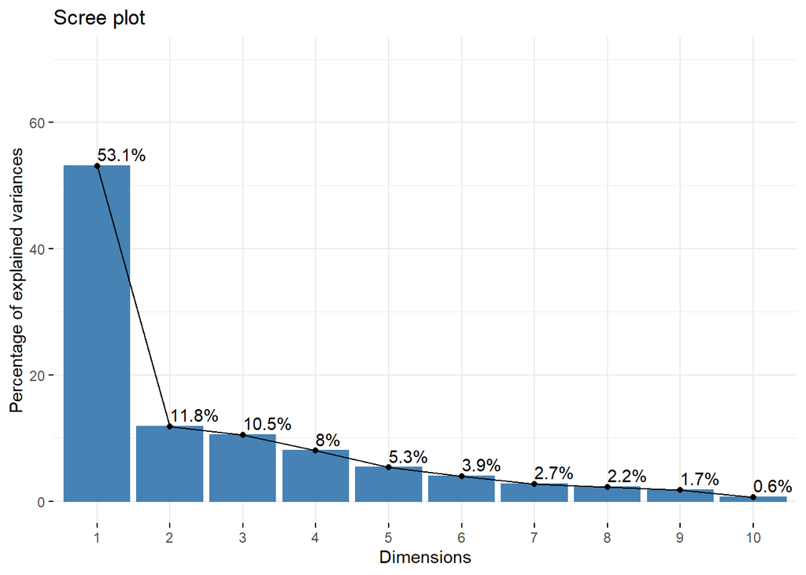

```r
## Gráfico de valores propios (eigenvalue)
fviz_eig(acp, addlabels = TRUE, ylim = c(0, 70))
```

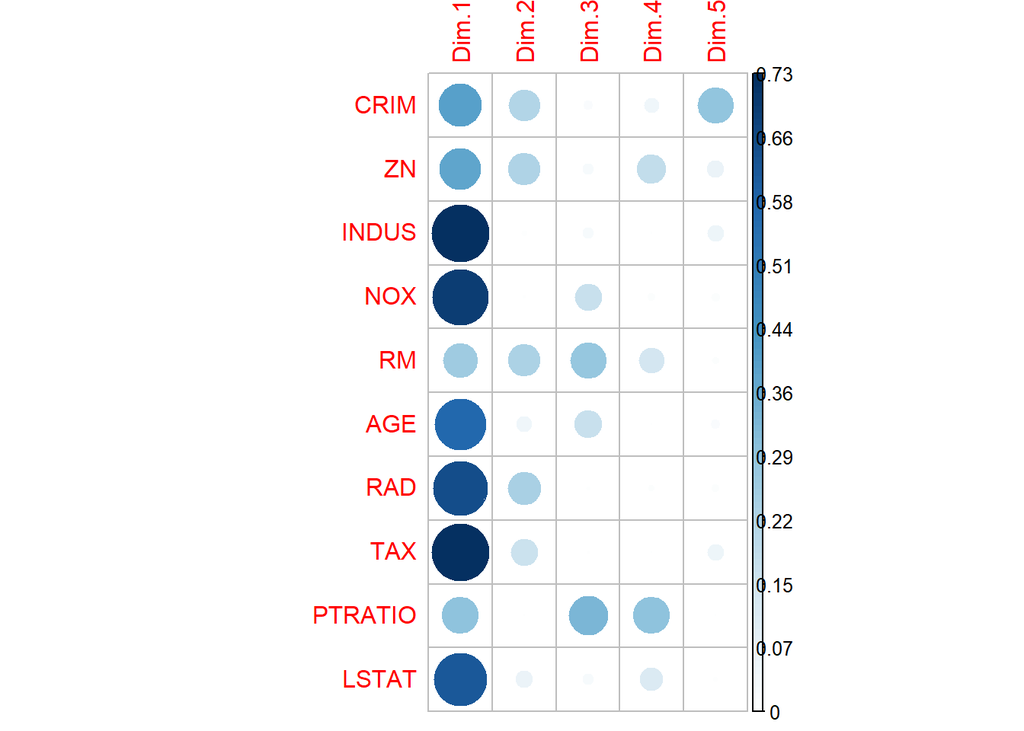

```r
## Extraigo las variables del análisis
var <- get_pca_var(acp)

## Carga de las variables
corrplot(var$cos2, is.corr=FALSE)
```

> Podemos reducir la dimensión del conjunto de datos de 10 variables de interés a 3 nuevas variables llamadas **componentes principales**. Incluso podríamos quedarnos con dos componentes principales según el criterio gráfico del codo.

**Construccion de las nuevas variables**

Asumamos que nos vamos a quedar con 2 componentes principales. En la práctica, eso implica que debemos agregar dos nuevas variables a nuestra base de datos:

- Componente 1
- Componente 2

¿Cómo calcular los valores que irían en las celdas?

El análisis por componentes principales nos genera nuevas variables que son una **combinación lineal** de las variables originales.

```r
## Extraemos las cargas de cada variable en cada componente
cargas = sweep(acp$var$coord,2,sqrt(acp$eig[1:ncol(acp$var$coord),1]),FUN="/")
cargas
```

```
##              Dim.1       Dim.2       Dim.3       Dim.4       Dim.5
## CRIM     0.2732876  0.42302829 -0.13585941  0.23844397 -0.73597627
## ZN      -0.2675745  0.43440206 -0.16031511  0.47779984  0.34782714
## INDUS    0.3707199 -0.07548864  0.15972327 -0.02060390  0.33129950
## NOX      0.3596725 -0.04368252  0.39245803  0.13110354  0.16347109
## RM      -0.2205641  0.44126370  0.52083700 -0.41442988 -0.13860143
## AGE      0.3288862 -0.20572769  0.39692598 -0.02993753 -0.19401704
## RAD      0.3490460  0.44846686 -0.05797233 -0.09661431  0.15602050
## TAX      0.3698465  0.36593177 -0.03809258 -0.02695204  0.33118721
## PTRATIO  0.2363546 -0.02046652 -0.56310943 -0.60854007  0.01123455
## LSTAT    0.3400330 -0.22858307 -0.15994056  0.37974859 -0.09933028
```

```r
## Veamos solo las cargas del primer componente
cargas[,1]
```

```
##       CRIM         ZN      INDUS        NOX         RM        AGE        RAD
##  0.2732876 -0.2675745  0.3707199  0.3596725 -0.2205641  0.3288862  0.3490460
##        TAX    PTRATIO      LSTAT
##  0.3698465  0.2363546  0.3400330
```

Con estos valores podemos calcular el valor del primer componente por medio de una combinación lineal de las variables originales:

```r
0.27*CRIM - 0.26*ZN + 0.37*INDUS + 0.35*NOX - 0.22*RM + 0.32*AGE + 0.34*RAD + 0.36*TAX + 0.23*PTRATIO + 0.34*LSTAT
```

De igual manera procedemos con el segundo componente:

```r
cargas[,2]
```

```
##        CRIM          ZN       INDUS         NOX          RM         AGE
##  0.42302829  0.43440206 -0.07548864 -0.04368252  0.44126370 -0.20572769
##         RAD         TAX     PTRATIO       LSTAT
##  0.44846686  0.36593177 -0.02046652 -0.22858307
```

Con estos valores podemos calcular el valor del segundo componente por medio de una combinación lineal de las variables originales:

```r
0.42*CRIM + 0.43*ZN - 0.07*INDUS - 0.04*NOX + 0.44*RM - 0.20*AGE + 0.44*RAD + 0.36*TAX - 0.02*PTRATIO - 0.22*LSTAT
```

Ya sabemos las ecuaciones de nuestros componentes, ahora los vamos a agregar a nuestra base de datos:

```r
## Definimos una función para hacer la multiplicación
## De cada variable en los datos estandarizados por su respectivo "ponderador"
calcpc <- function(variables,loadings)
{
  # Número de observaciones en el conjunto de datos
  as.data.frame(variables)
  numsamples <- nrow(variables)
  # Creamos un vector para alojar el componente
  pc <- numeric(numsamples)
  # Número de variables en el conjunto de datos
  numvariables <- length(variables)
  # Calculo del valor del componente para cada observacion
  for (i in 1:numsamples)
  {
    valuei <- 0
    for (j in 1:numvariables)
    {
      valueij <- variables[i,j]
      loadingj <- loadings[j]
      valuei <- valuei + (valueij * loadingj)
    }
    pc[i] <- valuei
  }
  return(unlist(pc))
}

## Cálculo del primer componente
comp1 = calcpc(data_estandarizada, cargas[,1])

## Cálculo del segundo componente
comp2 = calcpc(data_estandarizada, cargas[,2])

## Agregamos los componentes a la base de datos
data %>%
  add_column(comp1 = comp1, comp2 = comp2) -> data_con_componentes

## Podemos crear una versión reducida de nuestro conjunto de datos
data_con_componentes %>%
  select(comp1, comp2, MEDV) -> data_reducida

## Variación en la dimensionalidad de los datos
dim(data)
```

```
## [1] 506  14
```

```r
dim(data_estandarizada)
```

```
## [1] 506  10
```

```r
dim(data_con_componentes)
```

```
## [1] 506  16
```

```r
dim(data_reducida)
```

```
## [1] 506   3
```

## Observación de cierre

Todo el análisis multivariado realizado hasta el momento se ha enfocado en entender el comportamiento de las **variables (columnas)**. Siguiendo los mismos principios y herramientas de análisis, podríamos enfocarnos también en las **observaciones (filas)** e igualmente buscar similitudes, diferencias y grupos de individuos.